[figure not shown]

# Factores asociados a la confianza política:

## **Una aproximación empírica a partir del caso chileno**

**Juan Pablo Díaz**  
Examen de Título Sociología  
Comisión: Juan Carlos Castillo, Pablo Perez y Rodrigo Baño  
12 de enero de 2026

# Introducción

## Contexto

[figure not shown]

[figure not shown]

[figure not shown]

[figure not shown]

# ¿Qué factores inciden en la construcción de los juicios de confianza política?

## Confianza política: antecedentes

- “…expectativa de que las instituciones políticas funcionen según reglas justas incluso en ausencia de escrutinio constante” (Marien, 2013, p. 16)<sup>1</sup>.
- Dos grupos de factores que explicarían su origen (Mishler & Rose, 2001; Van der Meer & Zmerli, 2017; Zmerli, 2022):
  - Institucional: evaluación racional del **desempeño institucional** en distintos ámbitos de interés. Desempeño económico, corrupción y distribución de ingresos.
  - Sociocultural: **conjunto de orientaciones valóricas y disposiciones** a cooperar con los otros según objetivos comunes. Tiene su pilar en la **confianza generalizada**.
[^1]: Traducción propia.

## Problematización

- Conclusiones previas: la percepción del desempeño institucional **importaría más** para la confianza política que la confianza generalizada.
  1. Conciben la relación entre confianza generalizada y confianza política como un vínculo **exclusivamente** directo, ignorando su **potencial moderador**.
  2. Se han construido sobre información de **sociedades de alta confianza generalizada**. Es posible encontrar un panorama diferente en **sociedades de baja confianza generalizada**.

## El caso chileno

Figura 1: **Evolución de la confianza política en Chile: porcentaje de encuestados que reporta ‘mucha’ o ‘algo’ de confianza.**

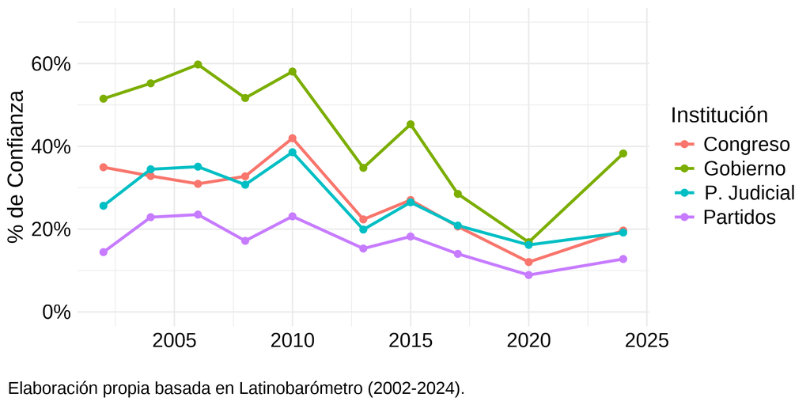

# ¿Cómo influyen la percepción del desempeño institucional y la confianza generalizada en la confianza política de los ciudadanos chilenos?

## Percepción del desempeño institucional

- **Desempeño económico**: capacidad de incrementar los estándares de vida de la población (McAllister, 1999; Quaranta & Martini, 2016; Thomassen, 1998).
- **Corrupción**: capacidad de resguardar el principio de transparencia en el aparato público (Beesley & Hawkins, 2022; Uslaner, 2013).
- **Justicia distributiva**: capacidad de asegurar una distribución de ingresos igualitaria, equitativa y suficiente. (Tyler, 2015; Zmerli & Castillo, 2015).

## Hipótesis

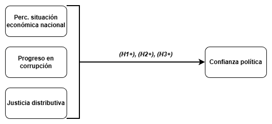

## Confianza generalizada

- Confianza que se deposita sobre **la mayoría de la gente**. **Disposición moral** a confiar según el resto es parte de nuestra comunidad moral (Uslaner, 2002).
- Lente a través del cual se interpreta el mundo de forma positiva, creyendo en la **buena voluntad** de los demás y cooperando con ellos (Oskarsson, 2010).
- Quienes confían en los otros serían **menos sensibles a disminuir su confianza política** en función de una evaluación negativa de su desempeño al corto plazo.

## Hipótesis

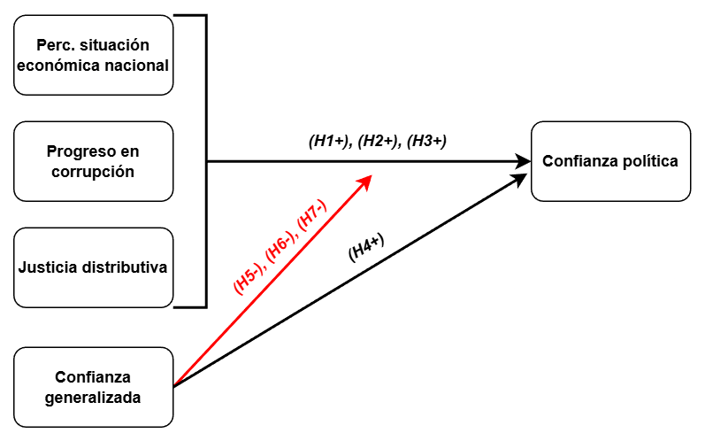

## Particularidades del caso chileno

- Baja confianza política convive con **mejoras** en indicadores económicos, baja corrupción y disminución de la desigualdad.
- Explicación complementaria:
  - **Baja confianza generalizada**: Solo un 15% de los chilenos dice confiar en los demás (PNUD, 2024).
- *H8*: en Chile, la confianza generalizada presenta una asociación con la confianza política **de mayor magnitud** que la percepción del desempeño institucional.

# Estrategia de análisis

## Metodología

- **Encuesta Latinobarómetro 2024**. Muestra de 1200 entrevistados. Probabilistica en tres etapas. Representativa del 100% de la población adulta urbana. 944 observaciones utilizadas para el análisis (sin *NA* ni observaciones influyentes).
- Análisis transversal: caracter exploratorio del estudio.
- Para los análisis, se construyeron un total de seis **modelos de regresión lineal (MCO)** siguiendo una estrategia incremental.

## Variables principales

[output not shown]

# Resultados

## Bivariados: situación económica y confianza política

Figura 2: **Gráfico de dispersión suavisado: situación económica y confianza política**

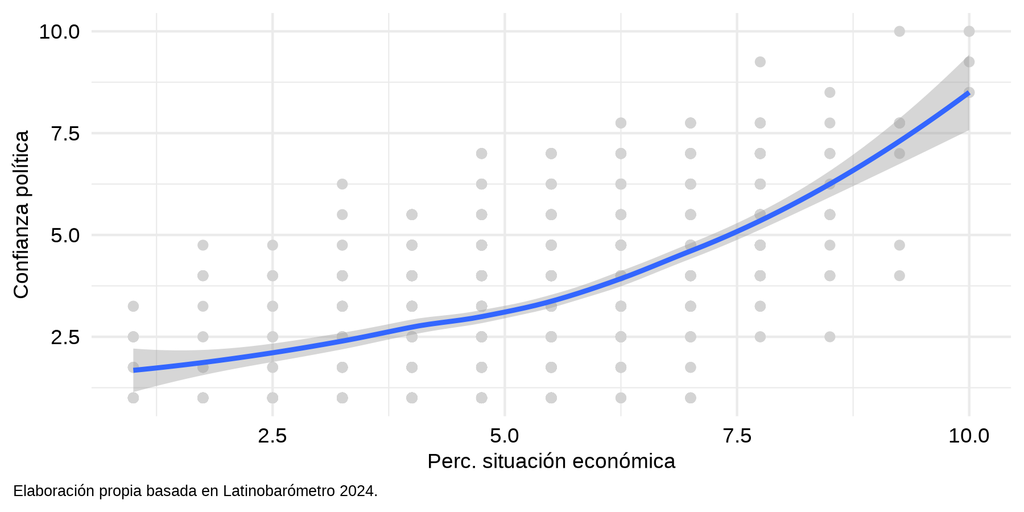

## Bivariados: progreso en reducir corrupción y confianza política

Figura 3: **Gráfico de barras: corrupción y confianza política

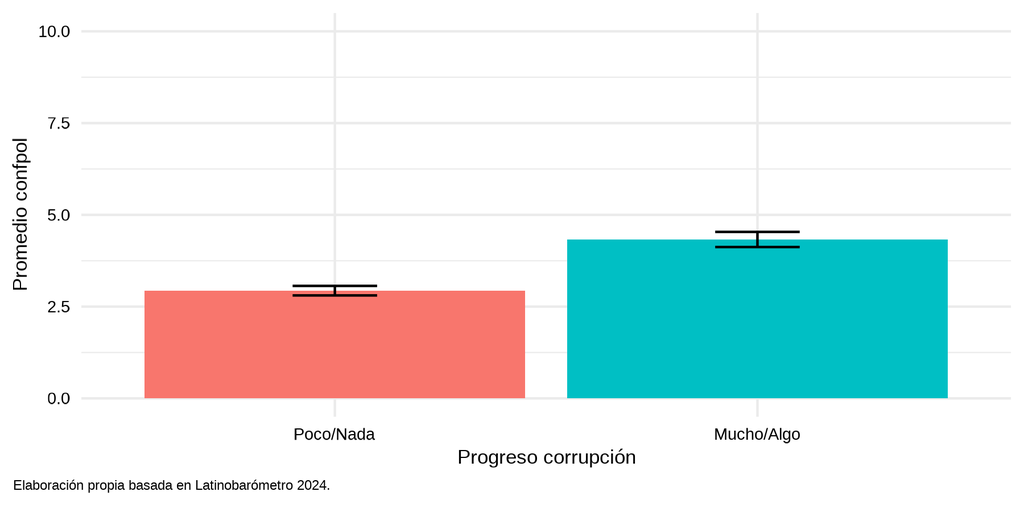

## Bivariados: justicia distributiva y confianza política

Figura 4: **Gráfico de barras: justicia distributiva y confianza política**

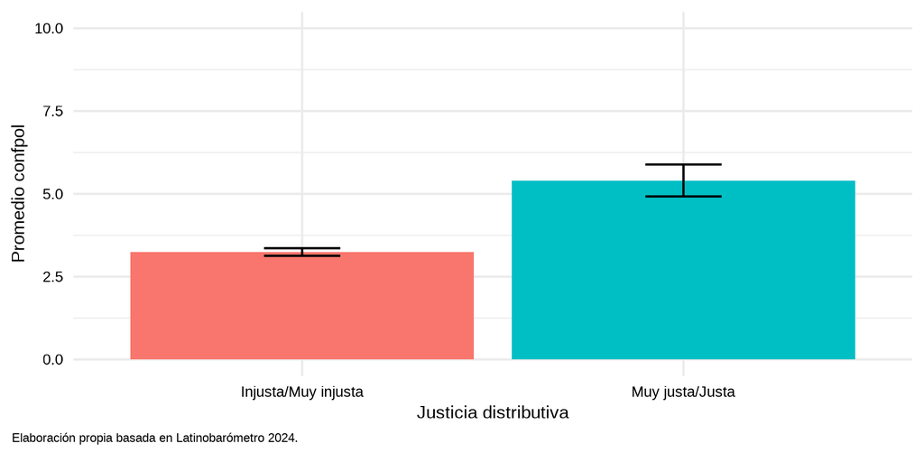

## Bivariados: confianza generalizada y confianza política

Figura 5: **Gráfico de barras: confianza generalizada y confianza política**

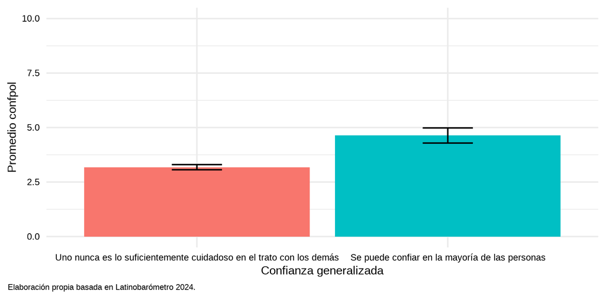

## Resultados regresiones

Figura 6: **Gráfico coeficientes modelos 3, 4 y 6**

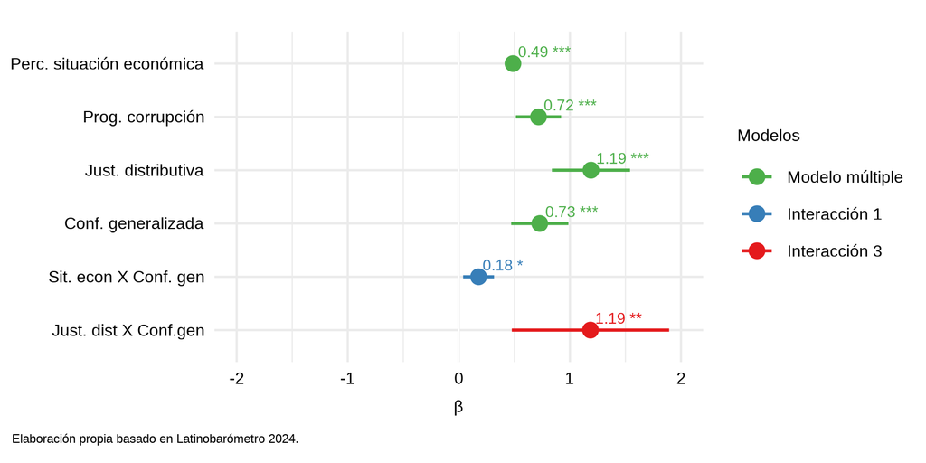

# Discusión

## Primer hallazgo

1. Las tres variables de percepción del desempeño se **relacionan positivamente con la confianza política** (*H1*, *H2* y *H3*). La corrupción y la justicia distributiva inciden más que el desempeño económico.
   1. Escándalos de corrupción pública (Luna, 2016).
   2. Politización de las desigualdades (Castiglioni & Rovira Kaltwasser, 2016).

## Segundo hallazgo

2. La confianza generalizada presenta una relación positiva con la confianza política (*H4*). A su vez, **modera positivamente** la relación que el desempeño económico y la justicia distributiva tienen con la confianza política (*H5* y *H7*).
   1. Ideal igualitario asociado a la confianza generalizada (Uslaner, 2002).
   2. Malos desempeños –> distanciamiento del ideal.
   3. ¿Y la corrupción?

## Tercer hallazgo

# Conclusiones

- **Más allá de la dicotomía**: la confianza política es un **fenómeno complejo**, en cuya construcción inciden tanto la evaluación racional del desempeño como la disposición moral a confiar en los demás.
- **Más allá del vínculo directo**: es necesario prestar atención al **efecto moderador** de la confianza generalizada.
- **Mas allá de Europa y EEUU**: en sociedades de baja confianza generalizada, este atributo puede tener una **mayor importancia relativa**.

# Comentarios profesor lector

- Definiciones y justificaciones en la **introducción**.
- Justificación mecanismo detrás del supuesto **efecto moderador negativo** de la confianza generalizada.
- Incluir **Análisis Factorial Exploratorio.**

# ¡Gracias por su atención!

- **Github del proyecto:** https://github.com/jp-diaz-c/tesis-final

## Referencias

Anderson, C. J., & Singer, M. M. (2008). The Sensitive Left and the Impervious Right: Multilevel Models and the Politics of Inequality, Ideology, and Legitimacy in Europe. *Comparative Political Studies*, *41*(4-5), 564-599. https://doi.org/10.1177/0010414007313113

Araujo, K. (2025). *El Circuito Del Desapego. Neoliberalismo, Democratización y Lazo Social*. Pólvora Editorial.

Beesley, C., & Hawkins, D. (2022). Corruption, Institutional Trust and Political Engagement in Peru. *World Development*, *151*, 105743. https://doi.org/10.1016/j.worlddev.2021.105743

Castiglioni, R., & Rovira Kaltwasser, C. (2016). Challenges to Political Representation in Contemporary Chile. *Journal of Politics in Latin America*, *8*(3), 3-24. https://doi.org/10.1177/1866802X1600800301

Citrin, J., & Stoker, L. (2018). Political Trust in a Cynical Age. *Annual Review of Political Science*, *21*(Volume 21, 2018), 49-70. https://doi.org/10.1146/annurev-polisci-050316-092550

Luna, J. P. (2016). Delegative Democracy Revisited: Chile’s Crisis of Representation. *Journal of Democracy*, *27*(3), 129-138.

Marien, S. (2013). Measuring Political Trust across Time and Space. En *Political Trust: Why Context Matters*. ECPR Press.

McAllister, I. (1999). The Economic Performance of Governments. En P. Norris (Ed.), *Critical Citizens* (1.ª ed., pp. 188-203). Oxford University PressOxford. https://doi.org/10.1093/0198295685.003.0009

Mishler, W., & Rose, R. (2001). What Are the Origins of Political Trust?: Testing Institutional and Cultural Theories in Post-communist Societies. *Comparative Political Studies*, *34*(1), 30-62. https://doi.org/10.1177/0010414001034001002

Montero Gibert, J. R., Zmerli, S., & Newton, K. (2008). Confianza Social, Confianza Política y Satisfacción Con La Democracia. *Revista Española de Investigaciones Sociológicas*, *122*, 11-54. https://doi.org/10.5477/cis/reis.122.11

Newton, K., Stolle, D., & Zmerli, S. (2017). Social and Political Trust. En E. M. Uslaner (Ed.), *The Oxford Handbook of Social and Political Trust* (Vol. 1). Oxford University Press. https://doi.org/10.1093/oxfordhb/9780190274801.001.0001

Oskarsson, S. (2010). Generalized Trust and Political Support: A Cross-National Investigation. *Acta Politica*, *45*(4), 423-443. https://doi.org/10.1057/ap.2010.3

PNUD. (2024). *Informe Sobre Desarrollo Humano En Chile 2024. Qué Nos Cuesta Cambiar?: Conducir Los Cambios Para Un Desarrollo Humano Sostenible.* Programa de las Naciones Unidas para el Desarrollo (PNUD).

Quaranta, M., & Martini, S. (2016). Does the Economy Really Matter for Satisfaction with Democracy? Longitudinal and Cross-Country Evidence from the European Union. *Electoral Studies*, *42*, 164-174. https://doi.org/10.1016/j.electstud.2016.02.015

Thomassen, J. (1998). Support for Democratic Values. En H.-D. Klingemann & D. Fuchs (Eds.), *Citizens and the State* (1.ª ed.). Oxford University PressOxford. https://doi.org/10.1093/0198294735.001.0001

Tyler, T. R. (2015). Social Justice. En *APA Handbook of Personality and Social Psychology, Volume 2: Group Processes* (pp. 95-122). American Psychological Association. https://doi.org/10.1037/14342-004

Uslaner, E. M. (1999). Democracy and Social Capital. En M. E. Warren (Ed.), *Democracy and Trust* (pp. 121-150). Cambridge University Press. https://doi.org/10.1017/CBO9780511659959.005

Uslaner, E. M. (2002). *The Moral Foundations of Trust*. Cambridge University Press.

Uslaner, E. M. (2013). Corruption, the Inequality Trap and Trust in Goverment. En S. Zmerli & M. Hooghe (Eds.), *Political Trust: Why Context Matters*. ECPR Press.

Van der Meer, T., & Zmerli, S. (2017). The Deeply Rooted Concern with Political Trust. En S. Zmerli & T. Van Der Meer (Eds.), *Handbook on Political Trust*. Edward Elgar Publishing. https://doi.org/10.4337/9781782545118

Zmerli, S. (2022). Political Trust. En *Encyclopedia of Quality of Life and Well-Being Research* (pp. 1-4). Springer, Cham. https://doi.org/10.1007/978-3-319-69909-7_2202-2

Zmerli, S., & Castillo, J. C. (2015). Income Inequality, Distributive Fairness and Political Trust in Latin America. *Social Science Research*, *52*, 179-192. https://doi.org/10.1016/j.ssresearch.2015.02.003

Zmerli, S., & Newton, K. (2008). Social Trust and Attitudes toward Democracy. *Public Opinion Quarterly*, *72*(4), 706-724.

## Apéndice 1: AFE confianza poliítca.

| Variable | MR1 | Complexity | Uniqueness |
| --- | --- | --- | --- |
| Confianza en el congreso | 0.84 | 1.00 | 0.29 |
| Confianza en el gobierno | 0.55 | 1.00 | 0.70 |
| Confianza en el poder judicial | 0.75 | 1.00 | 0.44 |
| Confianza en los partidos políticos | 0.83 | 1.00 | 0.31 |

## Apéndice 2: AFE desempeño económico.

| Variable | MR1 | Complexity | Uniqueness |
| --- | --- | --- | --- |
| Situación económica actual | 0.70 | 1.00 | 0.51 |
| Situación económica pasada | 0.84 | 1.00 | 0.29 |
| Situación económica futura | 0.74 | 1.00 | 0.45 |

## Apéndice 3: Tablas de regresión sin interacción

|  | Modelo 1 |  | Modelo 2 |  | Modelo 3 |  |
| --- | --- | --- | --- | --- | --- | --- |
| Predictores | beta | se | beta | se | beta | se |
| Perc. situación económica nacional | 0.50 *** | 0.03 | 0.48 *** | 0.03 | 0.49 *** | 0.03 |
| Progreso en corrupción | 0.78 *** | 0.10 | 0.73 *** | 0.10 | 0.72 *** | 0.10 |
| Justicia distributiva | 1.44 *** | 0.18 | 1.25 *** | 0.18 | 1.19 *** | 0.18 |
| Conf. generalizada |  |  | 0.74 *** | 0.13 | 0.73 *** | 0.13 |
| Observations | 944 |  | 944 |  | 944 |  |
| R<sup>2</sup> / R<sup>2</sup> adjusted | 0.389 / 0.387 |  | 0.409 / 0.407 |  | 0.414 / 0.407 |  |
| * p<0.05 ** p<0.01 *** p<0.001 |  |  |  |  |  |  |

## Apéndice 4: Tablas de regresión con interacción

|  | Modelo 4 |  | Modelo 5 |  | Modelo 6 |  |
| --- | --- | --- | --- | --- | --- | --- |
| Predictores | beta | se | beta | se | beta | se |
| Perc. situación económica nacional X Conf. generalizada | 0.18 * | 0.07 |  |  |  |  |
| Prog. corrupción x Conf. generalizada |  |  | 0.06 | 0.26 |  |  |
| Just. distributiva X Conf. generalizada |  |  |  |  | 1.19 ** | 0.36 |
| Observations | 944 |  | 944 |  | 944 |  |
| R<sup>2</sup> / R<sup>2</sup> adjusted | 0.418 / 0.410 |  | 0.414 / 0.406 |  | 0.420 / 0.413 |  |
| * p<0.05 ** p<0.01 *** p<0.001 |  |  |  |  |  |  |

## Apéndice 5: Controles Modelo 3

|  | Modelo 3 |  |
| --- | --- | --- |
| Predictores | beta | se |
| Sexo | 0.15 | 0.09 |
| Edad | 0.00 | 0.00 |
| Religión: Católico | 0.02 | 0.11 |
| Religión: No católico | 0.21 | 0.16 |
| Universitario | 0.01 | 0.12 |
| ESS: Clase Media | -0.05 | 0.10 |
| ESS: Clase Alta/Media alta | 0.39 | 0.29 |
| Observations | 944 |  |
| R<sup>2</sup> / R<sup>2</sup> adjusted | 0.414 / 0.407 |  |
| * p<0.05 ** p<0.01 *** p<0.001 |  |  |

## Apendice 6: relevancia confianza política

- “En particular, los académicos suelen asumir que los ciudadanos desencantados son más propensos a **impulsar cambios radicales** en el sistema…”(Anderson & Singer, 2008, p. 572) <sup>1</sup>.
- “La afirmación fundamental es que las personas no estarán dispuestas a apoyar políticas que impliquen **riesgos o sacrificios personales** si no confían en el gobierno.” (Citrin & Stoker, 2018, p. 61).
- “La confianza política… **reduce la evasión fiscal**, facilita el **consentimiento de los perdedores políticos** y ayuda a allanar el camino hacia el acuerdo político y el compromiso” (Newton et al., 2017, p. 38).
[^2]: Traducción y énfasis propio.

## Distinciones confianza política

- Indicador intermedio de **apoyo político**, dirigido a las instituciones políticas del régimen (Montero Gibert et al., 2008; Zmerli, 2022).

## Regresiones con interacción: perc. situación económica X confianza generalizada

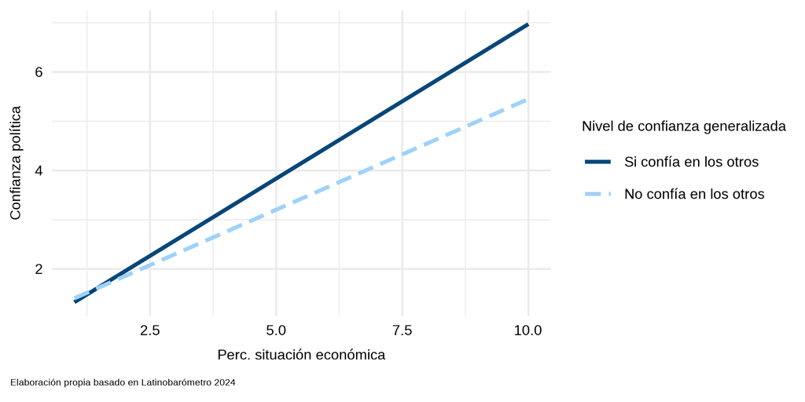

## Regresiones con interacción: justicia distributiva X confianza generalizada

Figura 8: **Gráfico interacción justicia distributiva con confianza generalizada**

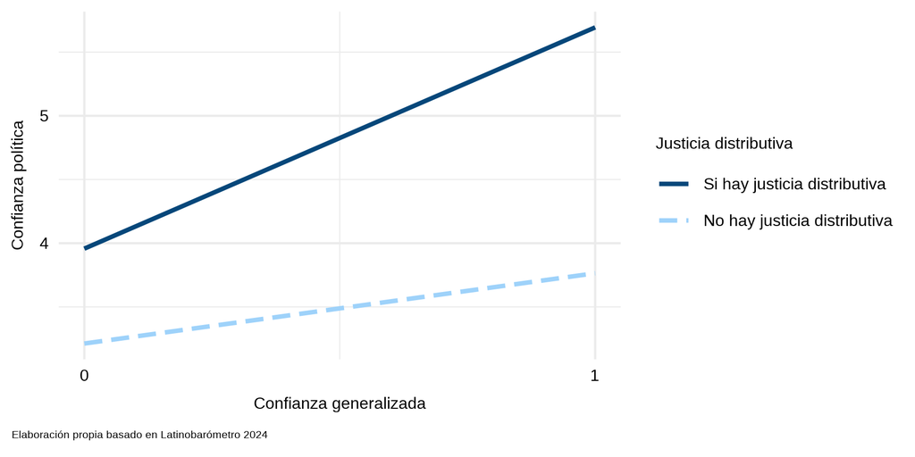

# Proyecciones

- Llevar a cabo modelos de tipo multinivel sobre **datos longitudinales** para analizar cómo estos efectos varían en el tiempo (si es que lo hacen).
- Incluir **variables contextuales** y compararlas con las de percepción.
- Expandir el radio de estudio hacia **mas países** de la región.

## El caso chileno: comparado

Figura 9: **Confianza política comparada en América Latina: promedio de confianza política.**

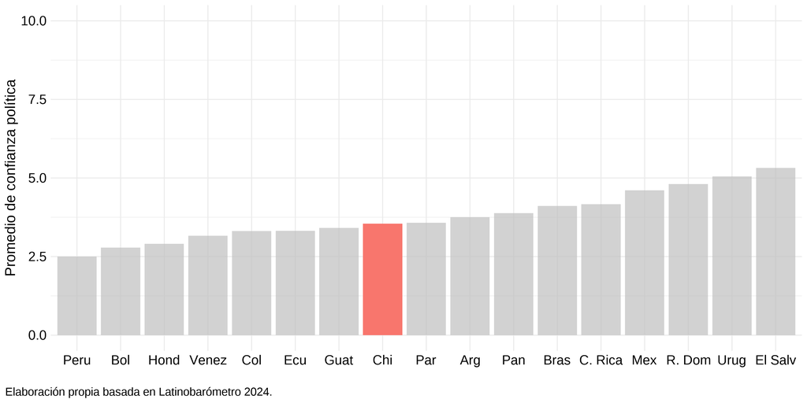